## Setup

### Load packages

```r
library(ggplot2)
library(dplyr)
library(statsr)
library(BAS)
```

### Load data

Make sure your data and R Markdown files are in the same directory. When loaded your data file will be called `movies`. Delete this note when before you submit your work.

```r
load("movies.Rdata")
```

## Part 1: Data

The data set is comprised of 651 randomly sampled movies produced and released before 2016.

Since the collection method was a random sample of more than 600 movies (of course way below 10% of the entire population - the number of movies produced in a year is probably higher than 20,000) this allows us to say that the insights we will retrieve from this data are generalizable and non-causual.

## Part 2: Data manipulation

```r
movies.red <- movies %>%
          mutate(feature_film = as.factor(ifelse(title_type == 'Feature Film', 'yes', 'no'))) %>%
          mutate(drama = as.factor(ifelse(genre == 'Drama', 'yes', 'no'))) %>%
          mutate(mpaa_rating_R = as.factor(ifelse(mpaa_rating == 'R', 'yes', 'no'))) %>%
          mutate(oscar_season=as.factor(ifelse(thtr_rel_month %in% c(10:12), 'yes', 'no'))) %>%
          mutate(summer_season=as.factor(ifelse(thtr_rel_month %in% c(5:8), 'yes', 'no'))) %>%
          filter(!is.na(runtime)) %>%
          select(feature_film, drama, runtime, mpaa_rating_R, thtr_rel_year, oscar_season, summer_season,
                 imdb_rating, imdb_num_votes, critics_score, audience_score, best_pic_nom, best_pic_win,
                 best_actor_win, best_actress_win, best_dir_win, top200_box)
```

## Part 3: Exploratory data analysis

After pre-processing the data, there were 650 movies in the movies.red dataset. The following charts show a breakdown of various movie characteristics.

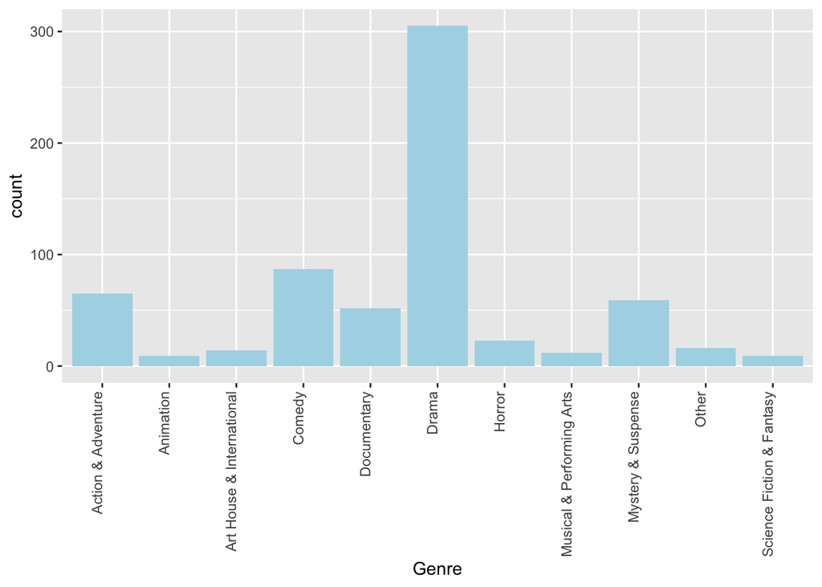

```r
ggplot(data = movies, aes(x = genre)) +
      geom_bar(fill = "light blue") +
      xlab("Genre") +
      theme(axis.text.x = element_text(angle = 90, hjust = 1, vjust = 0))
```

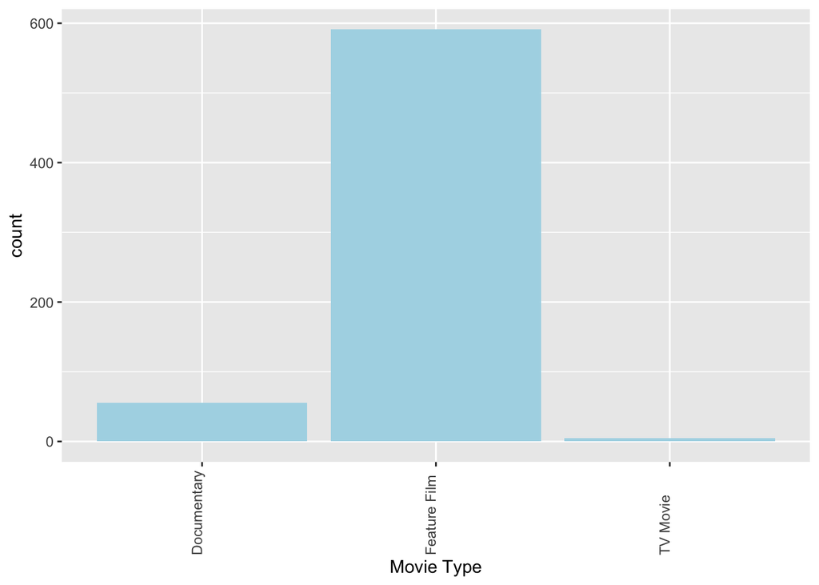

```r
ggplot(data = movies, aes(x = title_type)) +
      geom_bar(fill = "light blue") +
      xlab("Movie Type") +
      theme(axis.text.x = element_text(angle = 90, hjust = 0, vjust = 0))
```

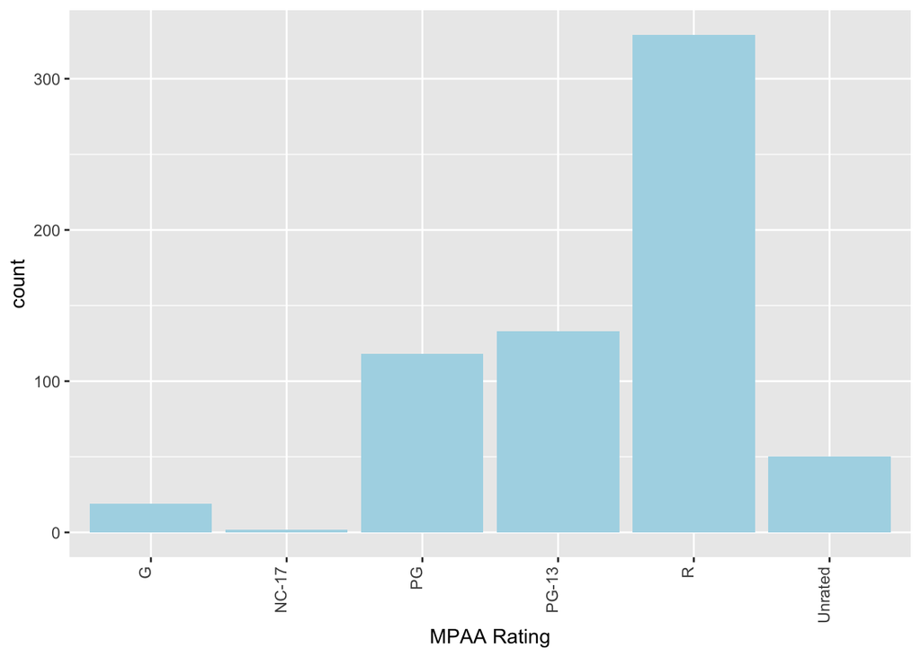

```r
ggplot(data = movies, aes(x = mpaa_rating)) +
      geom_bar(fill = "light blue") +
      xlab("MPAA Rating") +
      theme(axis.text.x=element_text(angle = 90, hjust = 1, vjust = 0))
```

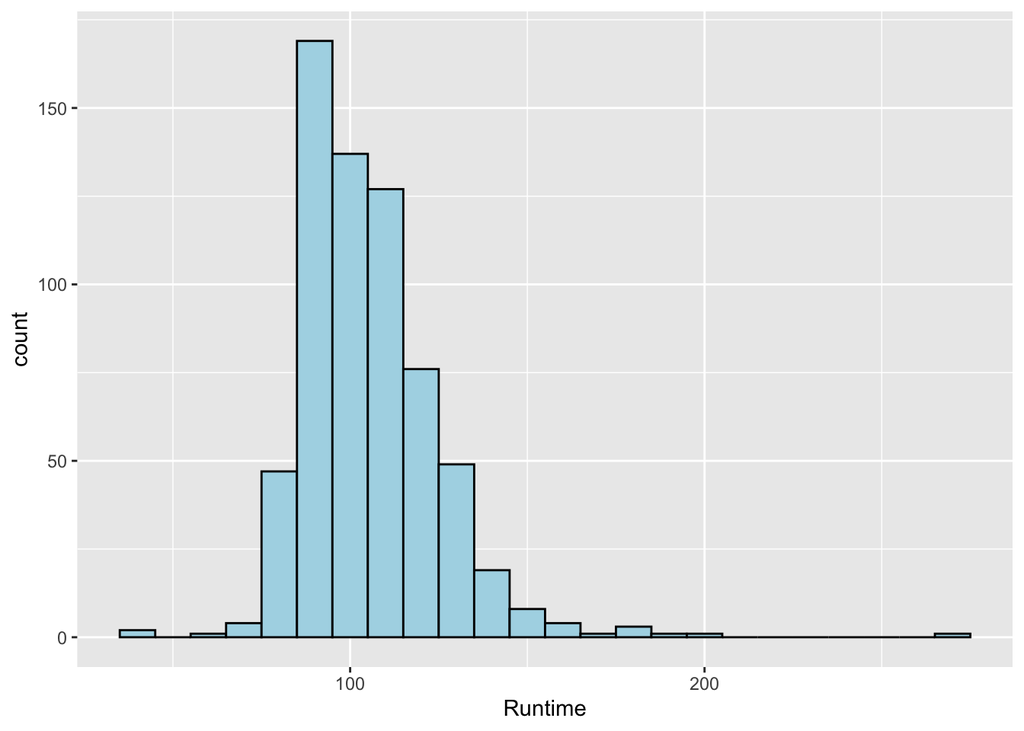

```r
ggplot(data = movies, aes(x = runtime)) +
      geom_histogram(binwidth = 10, fill = "light blue", col = "black") +
      xlab("Runtime")
```

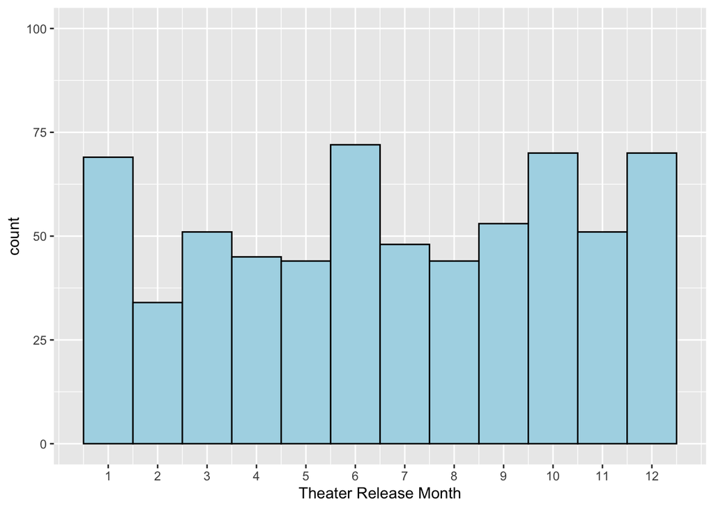

```r
ggplot(data = movies, aes(x = thtr_rel_month)) +
      geom_histogram(binwidth = 1, fill = "light blue", col = "black") +
      scale_x_continuous(breaks = c(1:12)) +
      scale_y_continuous(limits = c(0, 100)) +
      xlab("Theater Release Month")
```

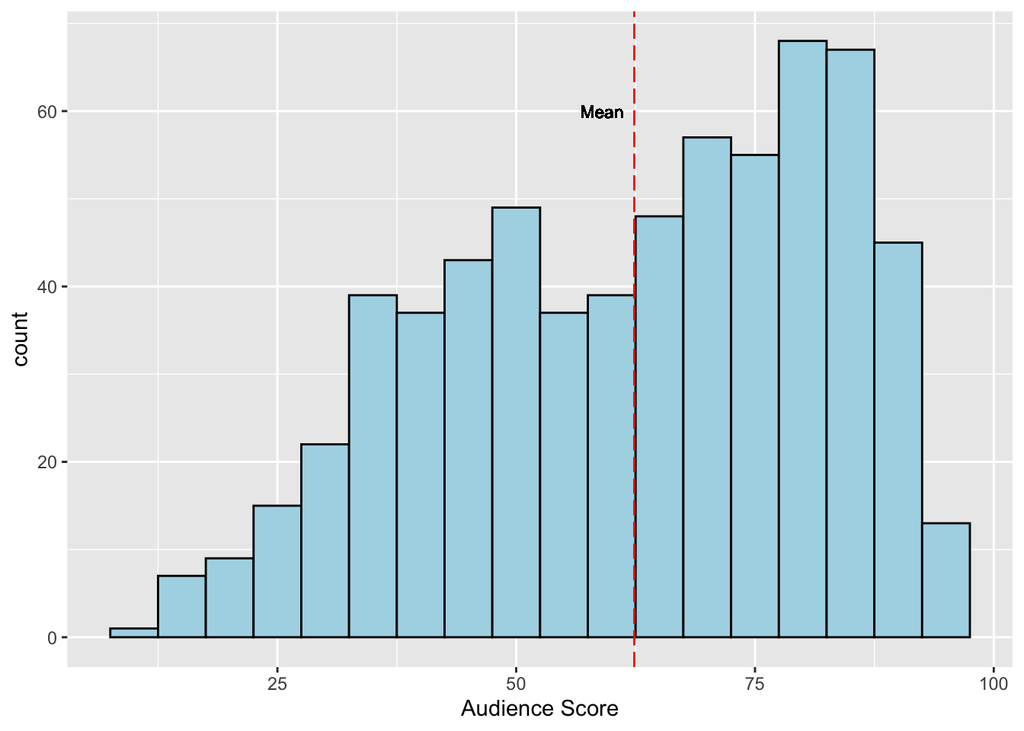

```r
ggplot(data = movies, aes(x = audience_score)) +
      geom_histogram(binwidth = 5, fill = "light blue", col = "black") +
      geom_vline(xintercept = mean(movies$audience_score), colour = 'red', linetype = 'longdash') +
      geom_text(label = 'Mean', x = 59, y = 60, hjust = 'center', size = 3) +
      xlab("Audience Score")
```

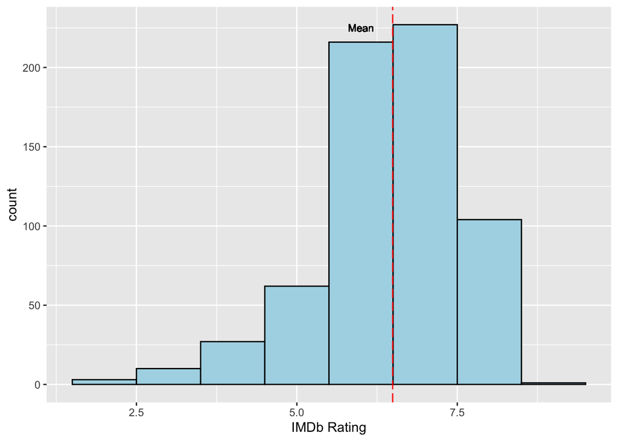

```r
ggplot(data = movies.red, aes(x = imdb_rating)) +
      geom_histogram(binwidth = 1, fill = "light blue", col = "black") +
      geom_vline(xintercept = mean(movies$imdb_rating), colour = 'red', linetype = 'longdash') +
      geom_text(label = 'Mean', x = 6, y = 225, hjust = 'center', size = 3) +
      xlab("IMDb Rating")
```

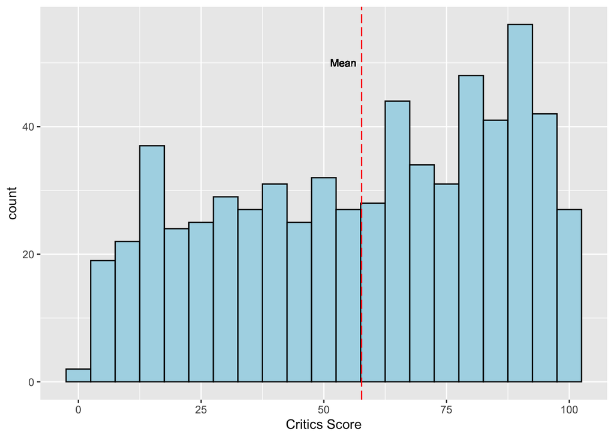

```r
ggplot(data = movies, aes(x = critics_score)) +
      geom_histogram(binwidth = 5, fill = "light blue", col = "black") +
      geom_vline(xintercept = mean(movies$critics_score), colour = 'red', linetype = 'longdash') +
      geom_text(label = 'Mean', x = 54, y = 50, hjust = 'center', size = 3) +
      xlab("Critics Score")
```

## Part 4: Modeling

Our goal is to predict the popularity of a movie - as quantified by the audience_score variable - using a bayesian regression model with all the predictors contained in the reduced dataset.

```r
bas.lm1 <- bas.lm(audience_score ~ ., data = movies.red, method = 'MCMC',
                 prior = 'ZS-null', modelprior = uniform())

summary(bas.lm1)
```

```
##                     P(B != 0 | Y)  model 1     model 2     model 3     model 4
## Intercept              1.00000000   1.0000   1.0000000   1.0000000   1.0000000
## feature_filmyes        0.06813126   0.0000   0.0000000   0.0000000   0.0000000
## dramayes               0.04627304   0.0000   0.0000000   0.0000000   0.0000000
## runtime                0.46508408   0.0000   1.0000000   0.0000000   0.0000000
## mpaa_rating_Ryes       0.20285034   0.0000   0.0000000   1.0000000   0.0000000
## thtr_rel_year          0.09551163   0.0000   0.0000000   0.0000000   0.0000000
## oscar_seasonyes        0.07796936   0.0000   0.0000000   0.0000000   0.0000000
## summer_seasonyes       0.08263931   0.0000   0.0000000   0.0000000   0.0000000
## imdb_rating            0.99998550   1.0000   1.0000000   1.0000000   1.0000000
## imdb_num_votes         0.06161041   0.0000   0.0000000   0.0000000   0.0000000
## critics_score          0.87885742   1.0000   1.0000000   1.0000000   1.0000000
## best_pic_nomyes        0.13824539   0.0000   0.0000000   0.0000000   0.0000000
## best_pic_winyes        0.04125824   0.0000   0.0000000   0.0000000   0.0000000
## best_actor_winyes      0.14403687   0.0000   0.0000000   0.0000000   1.0000000
## best_actress_winyes    0.14562302   0.0000   0.0000000   0.0000000   0.0000000
## best_dir_winyes        0.06795578   0.0000   0.0000000   0.0000000   0.0000000
## top200_boxyes          0.04957047   0.0000   0.0000000   0.0000000   0.0000000
## BF                             NA   1.0000   0.8702806   0.2217602   0.2236679
## PostProbs                      NA   0.1396   0.1210000   0.0312000   0.0300000
## R2                             NA   0.7525   0.7549000   0.7539000   0.7539000
## dim                            NA   3.0000   4.0000000   4.0000000   4.0000000
## logmarg                        NA 443.9495 443.8105657 442.4433468 442.4519125
##                         model 5
## Intercept             1.0000000
## feature_filmyes       0.0000000
## dramayes              0.0000000
## runtime               1.0000000
## mpaa_rating_Ryes      1.0000000
## thtr_rel_year         0.0000000
## oscar_seasonyes       0.0000000
## summer_seasonyes      0.0000000
## imdb_rating           1.0000000
## imdb_num_votes        0.0000000
## critics_score         1.0000000
## best_pic_nomyes       0.0000000
## best_pic_winyes       0.0000000
## best_actor_winyes     0.0000000
## best_actress_winyes   0.0000000
## best_dir_winyes       0.0000000
## top200_boxyes         0.0000000
## BF                    0.2055844
## PostProbs             0.0278000
## R2                    0.7563000
## dim                   5.0000000
## logmarg             442.3676066
```

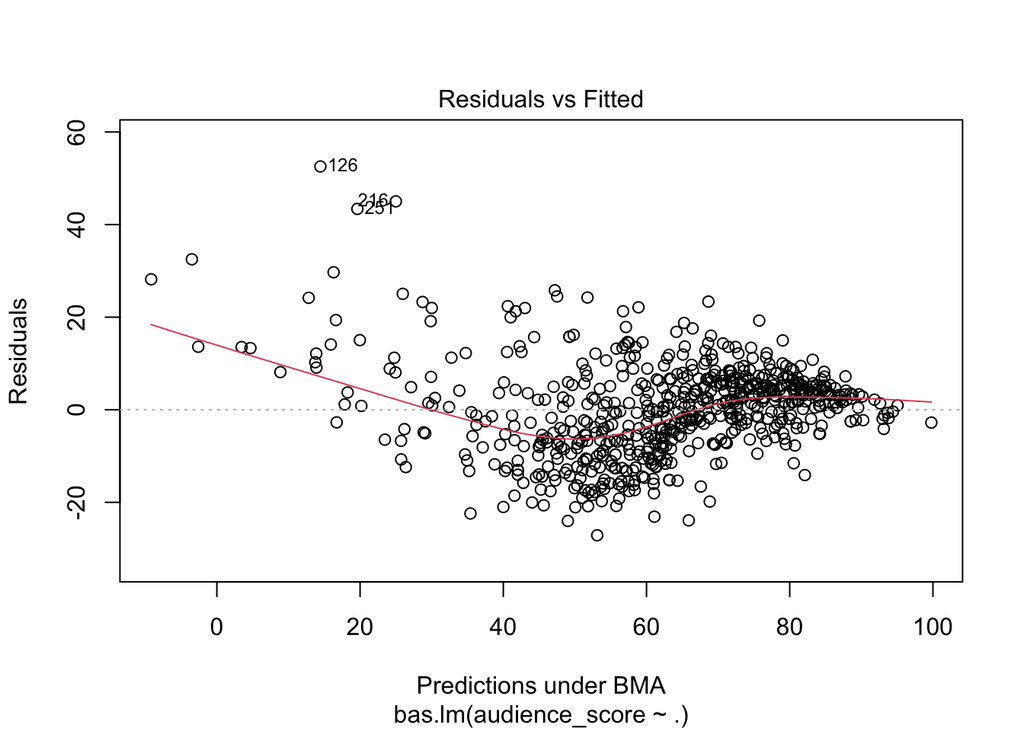

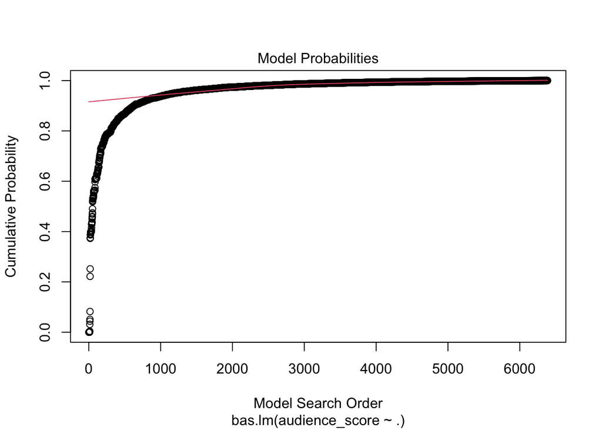

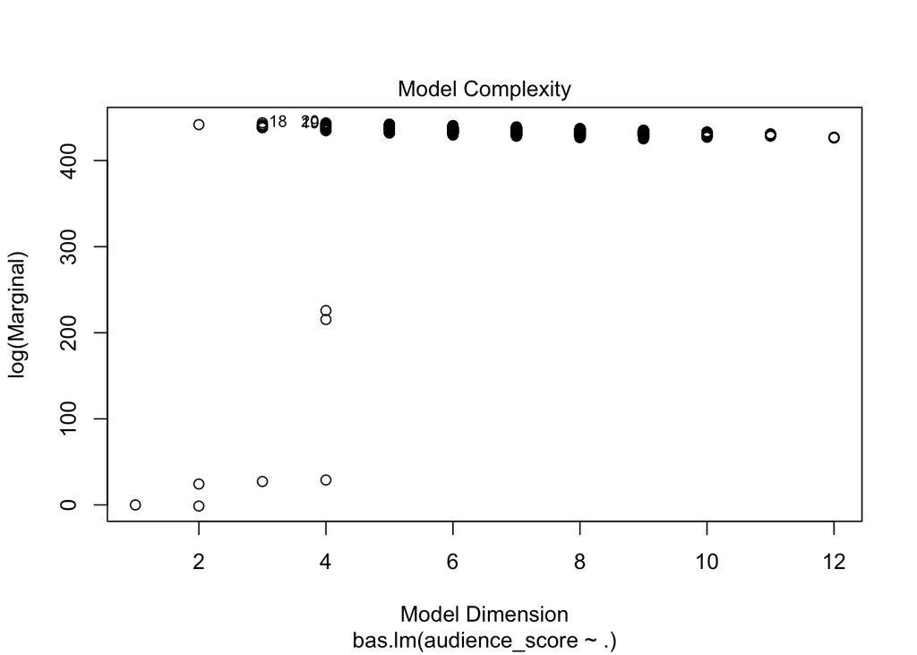

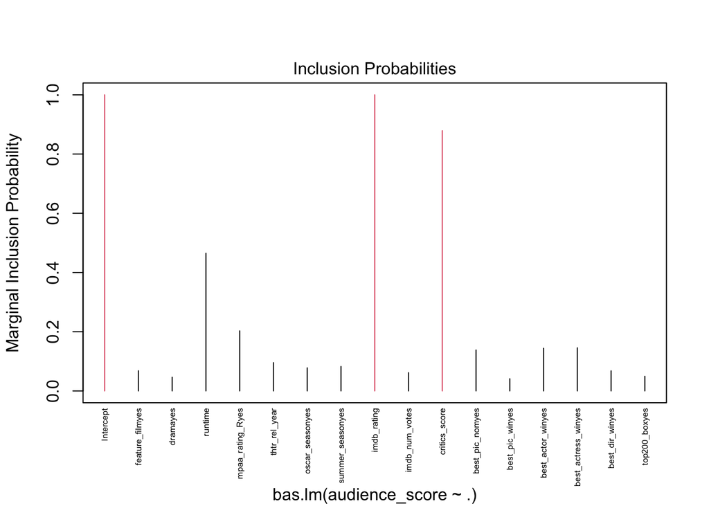

```r
plot(bas.lm1, cex.lab = 0.5)
```

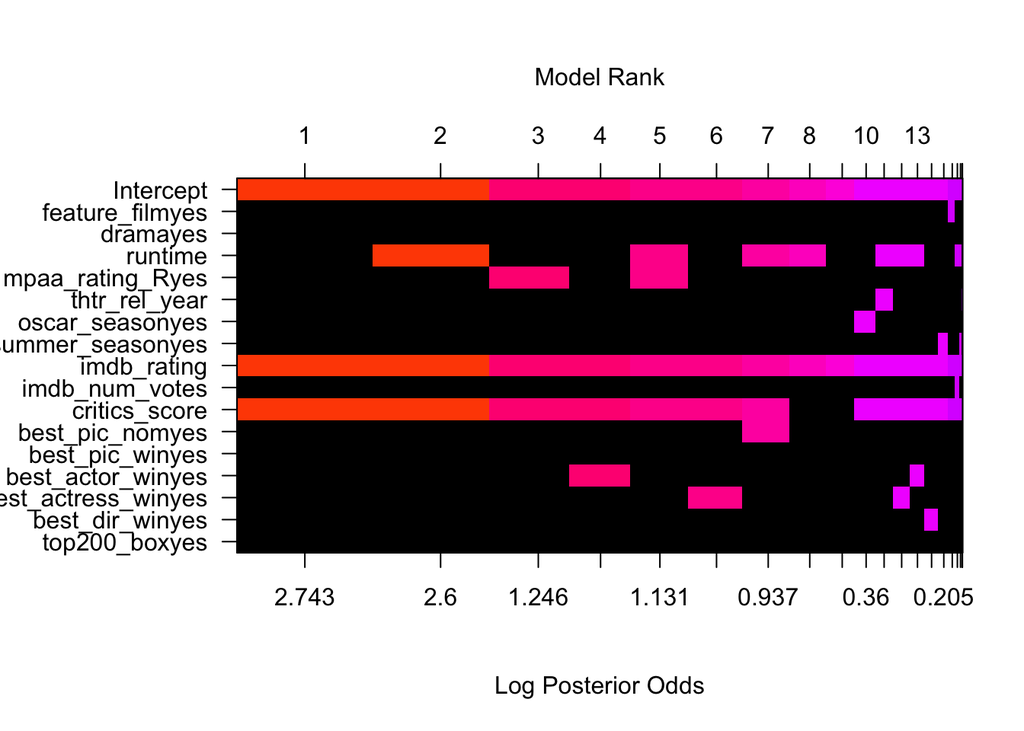

```r
image(bas.lm1, rotate = FALSE)
```

The diagnostic charts inform us about the fitness and soundness of the model.

The second chart shows that the model posterior probability density leveled off at 1 after approximately 3,000 model combinations had been sampled.

The model complexity chart is not very informative in this case, since several model specifications look very similar and their variance is more or less the same (at least from a visual point of view).

The last chart shows the inclusion probabilities of the predictors. The higher the marginal inclusion rate, the more the predictor was used in the models. We can check this also by looking at the last image, that shows exactly this for the top 20 models.

## Part 5: Prediction

Let’s try to predict the audience_score for the movie Dunkirk (2017). The data were obtained from IMDB, Rotten Tomatoes and Google researches.

```r
Dunkirk <- data.frame(runtime = 106,
                         thtr_rel_year = 2017,
                         imdb_rating = 7.9,
                         imdb_num_votes = 520686,
                         critics_score = 93,
                         audience_score = NA,
                         best_pic_nom = factor("yes", levels=c("no", "yes")),
                         best_pic_win = factor("no", levels=c("no", "yes")),
                         best_actor_win = factor("no", levels=c("no", "yes")),
                         best_actress_win = factor("no", levels=c("no", "yes")),
                         best_dir_win = factor("no", levels=c("no", "yes")),
                         top200_box = factor("no", levels=c("no", "yes")),
                         feature_film = factor("yes", levels=c("no", "yes")),
                         drama = factor("yes", levels=c("no", "yes")),
                         mpaa_rating_R = factor("no", levels=c("no", "yes")),
                         oscar_season = factor("no", levels=c("no", "yes")),
                         summer_season = factor("yes", levels=c("no", "yes")))

BMA_bas.lm1_dunkirk <- predict(bas.lm1, newdata = Dunkirk, estimator = "BMA", se.fit = TRUE)
summary(BMA_bas.lm1_dunkirk)
```

```
##             Length Class  Mode
## fit            1   -none- numeric
## Ybma           1   -none- numeric
## Ypred       6386   -none- numeric
## postprobs   6386   -none- numeric
## se.fit      6386   -none- numeric
## se.pred     6386   -none- numeric
## se.bma.fit     1   -none- numeric
## se.bma.pred    1   -none- numeric
## df          6386   -none- numeric
## best        6386   -none- numeric
## bestmodel   6386   -none- list
## best.vars     17   -none- character
## estimator      1   -none- character
```

```r
BMA_basLM1_predME <- qt(0.95, df = BMA_bas.lm1_dunkirk$se.bma.pred[1]) *
                     mean(BMA_bas.lm1_dunkirk$se.bma.pred)

df <- data.frame("Movie_Title" = "Dunkirk",
                 "Predicted_Rating" = sprintf("%2.1f", BMA_bas.lm1_dunkirk$Ybma),
                 "Prediction_Interval" = sprintf("%2.1f - %2.1f",
                                                     BMA_bas.lm1_dunkirk$Ybma - BMA_basLM1_predME,
                                                     BMA_bas.lm1_dunkirk$Ybma + BMA_basLM1_predME),
                 "Actual_Rating" = 81)
print(df)
```

```
##   Movie_Title Predicted_Rating Prediction_Interval Actual_Rating
## 1     Dunkirk             86.5        68.0 - 105.0            81
```

## Part 6: Conclusion

In this analysis, a parsimonious, linear regression model using bayesian model averaging was created that proved to have some capability for predicting movie popularity based on certain movie characteristics.

Dunkirk movie was predicted to have an 86.5 rating while the actual rating was just 81. This is a very decent result given the scoring scale (0-100).